# Problem 3

We need to procure 3000 lb. of cashews a week from the local market.

There are a couple of key considerations here:

1. Does the market sell out everyday?
2. What is the cost of one trip to the market?
3. What is the carrying capacity of our truck to the market, how does this scale in regards to more trucks?
4. How soon are these cashews distributed further?
   - Where are the cashews stored prior to further distribution?
5. What is the storage capacity of this distribution center?
   - How long can cashews be effectively stored?
   - How does the cost of storage scale?
6. How reliable are the market deliveries?
   - Are the cashews consistently of good quality year-round, or are some days/time periods better than others?
   - Where are they sourced from? How do delays in that supply chain affect the market deliveries?
7. How do the market prices change over time? Are they subject to supply/demand shocks and falls?
8. How much of the total supply to the market can we capture?
9. Are there are any other potential channels that could be tapped?

```python
import pandas as pd
import numpy as np
import matplotlib.pyplot as plt
from fbprophet import Prophet
from fbprophet.diagnostics import cross_validation
from fbprophet.diagnostics import performance_metrics
from fbprophet.plot import add_changepoints_to_plot
import itertools
np.random.seed(777)
```

```
Importing plotly failed. Interactive plots will not work.
```

```python
df = pd.read_csv('part_3_cashews.csv', parse_dates=['Date'], header=0)
```

Taking a look at the data we have there are some interesting observations to be made:

The price does not seem to be reflective of the net_weight,

- i.e. it seems that the price is not likely for the entire truck load but rather in units such as dollars per lb. of cashews
- There is also a strong upward trend in price over time

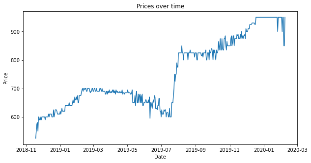

```python
plt.figure(figsize=(10,5))
plt.plot(df['Date'], df['price'])
plt.title('Prices over time')
plt.ylabel('Price')
plt.xlabel('Date')
plt.show()
```

Figuring out what caused the jump in price from July 2019 to August 2019 would be of pivotal importance

- Could such a situation repeat itself?
- How to predict the possibility of a reoccurence?

Assuming that the most important thing then is to make sure we have an adequate supply of 3000 lbs. per week, we could examine the historical trend to see how often 3000 lbs are available

```python
# Ounces to pounds
df['net_weight'] = df['net_weight'] / 16
```

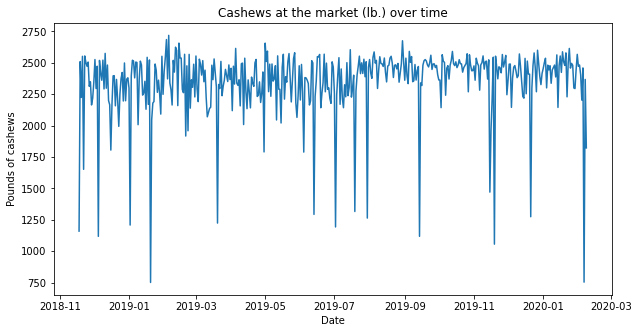

```python
plt.figure(figsize=(10,5))
plt.plot(df['Date'], df['net_weight'])
plt.title('Cashews at the market (lb.) over time')
plt.ylabel('Pounds of cashews')
plt.xlabel('Date')
plt.show()
```

```python
np.max(df['net_weight'])
```

```
2717.9375
```

- Cannot satisfy 3000 lb. weekly need with just one weekly trip to the market
- Problem becomes - how often to go to the market then, as to minimize trips but maximize amount of cashews obtained
- Therefore we look at the seasonality in these deliveries, are they completely random or is there a general pattern
  - e.g. Every Monday in general has more lbs. available than any given Tuesday, on average
  - If we can discover such patterns we can optimize our trips around these days

```
INFO:fbprophet:Disabling yearly seasonality. Run prophet with yearly_seasonality=True to override this.
INFO:fbprophet:Disabling daily seasonality. Run prophet with daily_seasonality=True to override this.
```

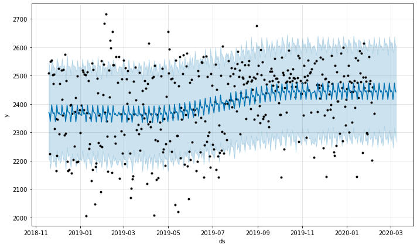

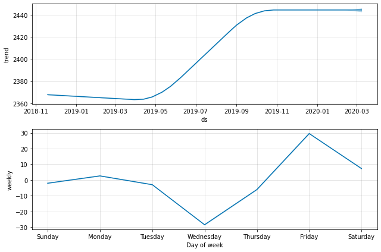

```python
# Simple Prophet model to extract seasonality
df1 = df[['Date','net_weight']]
df1 = df1[df1['net_weight'] > 2000] # Removing outliers
df1 = df1.rename(columns={df1.columns[0]: 'ds', df1.columns[1]: 'y'})
model = Prophet().fit(df1)
future = model.make_future_dataframe(periods=30, freq='D')
forecast = model.predict(future)
fig = model.plot(forecast)
fig2 = model.plot_components(forecast)
```

- While visually we can tell that the default Prophet model is not going so well, if we had the time necessary we could continue to iterate upon it until we get a better fit
- Then we could look at the weekly components and see which days have a higher propensity for deliveries